# LDdecay

M-n e chose exporter markdown export to html

for HTML C-u M-n e.

## R Markdown

Load R functions

```r
library(Relate)
library(snpStats)
```

```r
## change path to R file from githup
source("/home/albrecht/github/LDdecay/LDdecay.R")
if(FALSE){
    #to install
    library(devtools)
    install_github("aalbrechtsen/relate")
}

plink<-
function(plinkFile){
    pl <- snpStats::read.plink(plinkFile)
    ind<-pl$fam[,1]
    snp<-pl$map[,2]
    geno<-as.integer(as.integer(pl$genotypes)-1)
    dim(geno)<-c(length(ind),length(snp))
    geno[geno==-1]<-NA
    rownames(geno)<-ind
    colnames(geno)<-colnames(pl)
    bim<-read.table(paste0(plinkFile,".bim"),as.is=T,header=F)
    fam<-read.table(paste0(plinkFile,".fam"),as.is=T,header=F)
    list(geno=geno,bim=bim,fam=fam,pl=pl)
}
```

## read plink file

Plnk file with data used in example can be found at http://pontus.popgen.dk/albrecht/open/admixTjeck/plink/ (you will need the bed, bim and fam file)

```r
plinkFile <- "/home/albrecht/public/open/admixTjeck/plink/admixTjeck2"
pl <- plink(plinkFile)

popInfo <- pl$fam[,2]
 table(popInfo)
```

```
## popInfo
## CEU CHB MXL YRI
##  99 103  64 108
```

extract genotype for CEU population

```r
CEUgeno <- pl$geno[popInfo=="CEU",]
```

calculate LD and plot mean r2 where distance is number of SNPs. Where pairwise LD is calculated using a window of 101 SNPs (calculate LD with 50 previous SNPs). For larger windows then change depth (depth number of SNPs used on either side of focal SNP).

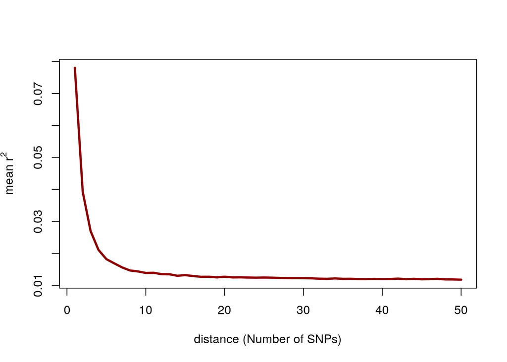

```r
## will only return r2 from same chromosome
ceuRes <- LDdecay(CEUgeno,pos=pl$bim[,4]/1e6,chr=pl$bim[,1],maf=0.05,mis=0.01,depth=50)
ylabr2 <- expression(paste("mean r"^"2"))
plot(ceuRes$SNPr2,type="l",lwd=3,col="darkred",ylab=ylabr2 ,xlab="distance (Number of SNPs)")
```

Bin based on physical distance in Mb (not the position was converted to Mb above). Max 1 Mb and 100 bins

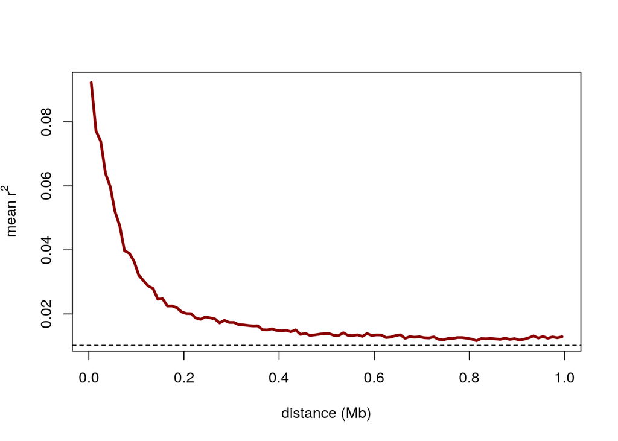

```r
ceuBin <- makeBin(ceuRes,max=1,n=100)
plot(ceuBin$seq,ceuBin$r2bin,type="l",lwd=3,col="darkred",ylab=ylabr2,xlab="distance (Mb)")
N <- nrow(CEUgeno)
abline(h=1/(N-1),lty=2)
```

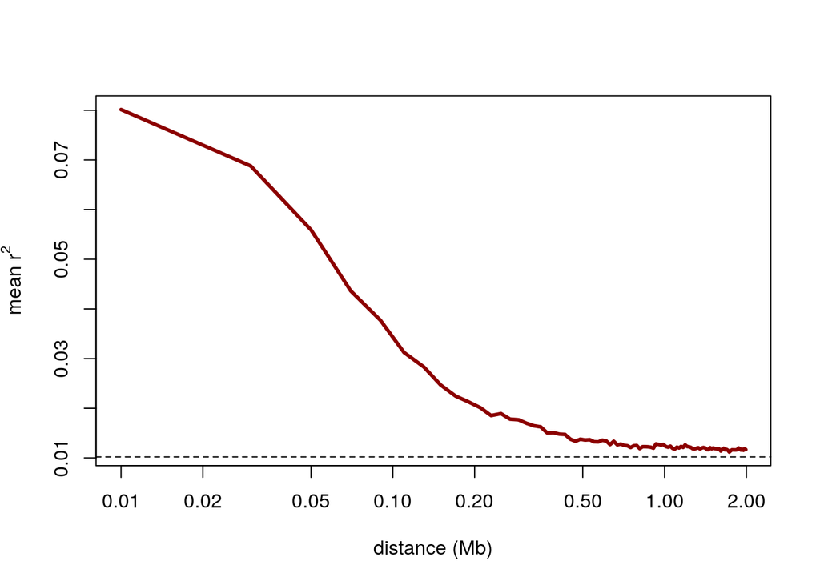

```r
ceuBin2 <- makeBin(ceuRes,max=2,n=100)
plot(ceuBin2$seq,ceuBin2$r2bin,type="l",lwd=3,col="darkred",ylab=ylabr2,xlab="distance (Mb)",log="x")
abline(h=1/(N-1),lty=2)
```

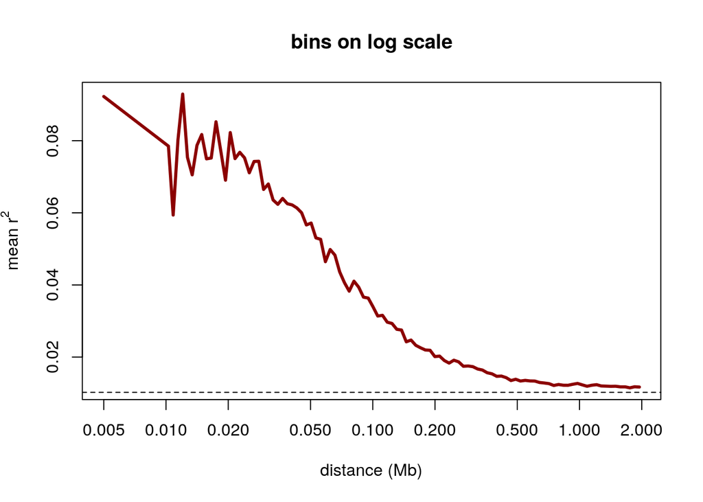

```r
#make the bins on log scale
ceuBin2log <- makeBin(ceuRes,max=2,n=100,log=T)
plot(ceuBin2log$seq,ceuBin2log$r2bin,type="l",lwd=3,col="darkred",ylab=ylabr2,xlab="distance (Mb)",log="x",main="bins on log scale")
abline(h=1/(N-1),lty=2)
```

See if you depth is high enough for 1Mb regions

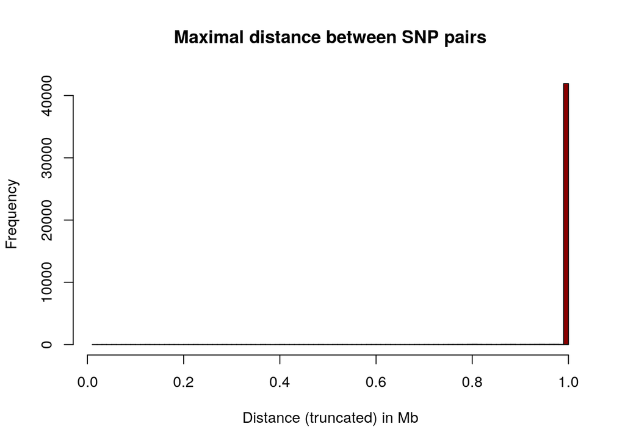

```r
dist <- ceuRes$r2[,"pos2"] - ceuRes$r2[,"pos1"]
## window size in Mb
maxDist <- tapply(dist,ceuRes$r2[,"pos1"],max)
target<- 1
#maxDist[maxDist>target] <- target
hist(ifelse(maxDist>target,target,maxDist),main="Maximal distance between SNP pairs",br=100,col="darkred",xlab="Distance (truncated) in Mb")
```

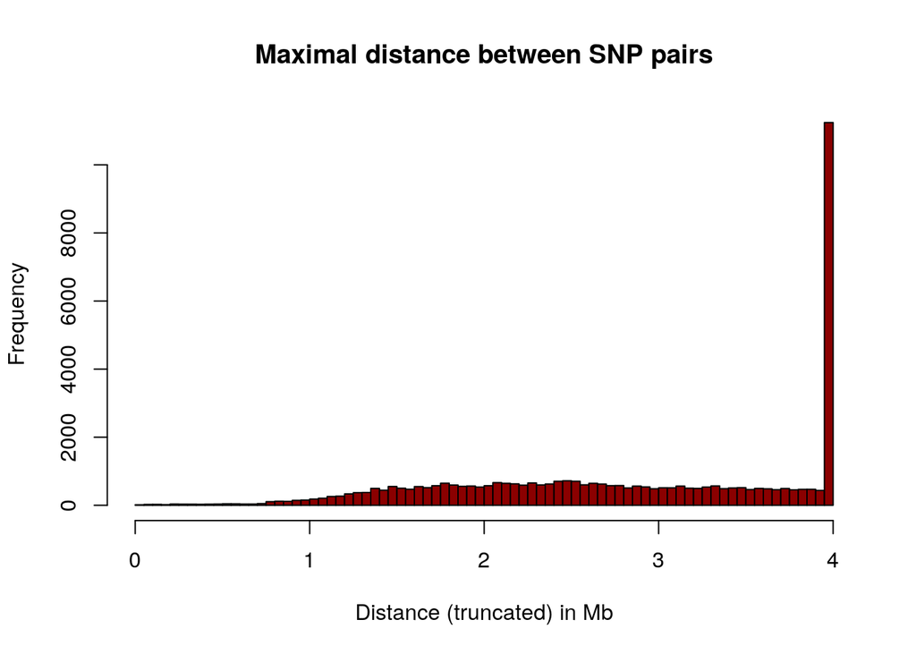

```r
target<- 4
hist(ifelse(maxDist>target,target,maxDist),main="Maximal distance between SNP pairs",br=100,col="darkred",xlab="Distance (truncated) in Mb")
```

We see that out depth is high enough for 1Mb but not optimal for 4 (many windows are shorter than 4 Mb).

# Now lets make the plot for multiple pops

lets do the same for the MXL and the YRI

```r
mxlRes <- LDdecay(pl$geno[popInfo=="MXL",],pos=pl$bim[,4]/1e6,chr=pl$bim[,1],maf=0.05,mis=0.01,depth=50)
mxlBin2 <- makeBin(mxlRes,max=2,n=100)
yriRes <- LDdecay(pl$geno[popInfo=="YRI",],pos=pl$bim[,4]/1e6,chr=pl$bim[,1],maf=0.05,mis=0.01,depth=50)
yriBin2 <- makeBin(yriRes,max=2,n=100)

Nall <- c(sum(popInfo=="MXL"),sum(popInfo=="CEU"),sum(popInfo=="YRI"))
```

Make plot

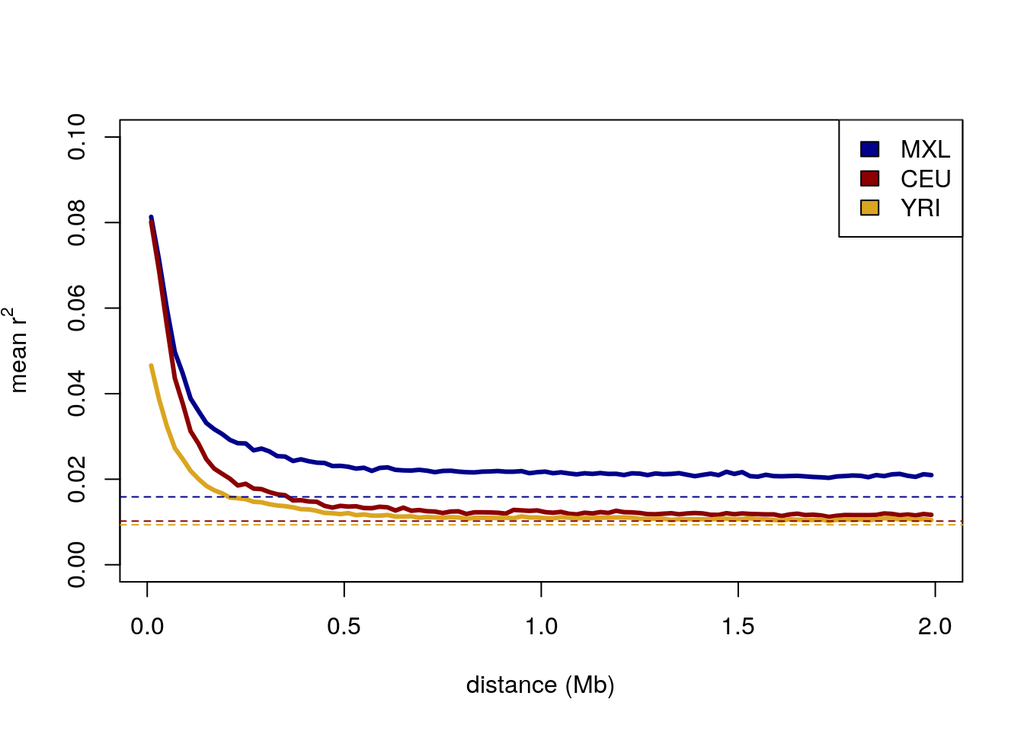

```r
mxlBinLog2 <- makeBin(mxlRes,max=2,n=100)
yriBin2 <- makeBin(yriRes,max=2,n=100)


plot(mxlBin2$seq,mxlBin2$r2bin,type="l",lwd=3,col="darkblue",ylab=ylabr2,xlab="distance (Mb)",ylim=c(0,0.1))
lines(ceuBin2$seq,ceuBin2$r2bin,lwd=3,col="darkred")
lines(yriBin2$seq,yriBin2$r2bin,lwd=3,col="goldenrod")
legend("topright",fill=c("darkblue","darkred","goldenrod"),c("MXL","CEU","YRI"))
abline(h=1/(Nall-1),lty=2,col=c("darkblue","darkred","goldenrod"))
```

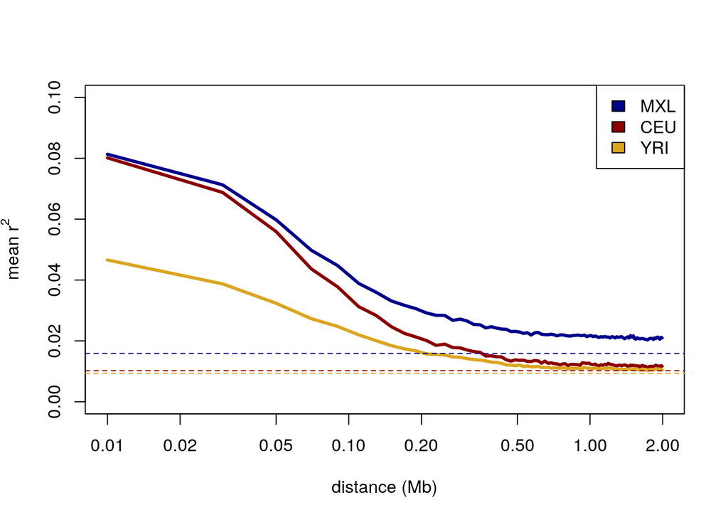

```r
plot(mxlBin2$seq,mxlBin2$r2bin,type="l",lwd=3,col="darkblue",ylab=ylabr2,xlab="distance (Mb)",ylim=c(0,0.1),log="x")
lines(ceuBin2$seq,ceuBin2$r2bin,lwd=3,col="darkred")
lines(yriBin2$seq,yriBin2$r2bin,lwd=3,col="goldenrod")
legend("topright",fill=c("darkblue","darkred","goldenrod"),c("MXL","CEU","YRI"))
abline(h=1/(Nall-1),lty=2,col=c("darkblue","darkred","goldenrod"))
```

From the decay curve we can see that YRI and CEU are not admixed (they converge to 1/(N-1)). There is some missing data and maybe a bit of relatedness or inbreeding which will give a sligt upward bias. The MXL are clearly admixed and will not converge to 1/(N-1).

Let add LD between chromosomes

```r
mxlBetween <- reform(mxlRes$ldResults$rmisc,pl$bim[mxlRes$keepSNP,4]/1e6 , pl$bim[mxlRes$keepSNP,1] ,betw=T)
mxlBtR2 <- mean(mxlBetween[,"r2"])
mxlBtR2
```

```
## [1] 0.02054069
```

```r
ceuBetween <- reform(ceuRes$ldResults$rmisc,pl$bim[ceuRes$keepSNP,4]/1e6 , pl$bim[ceuRes$keepSNP,1] ,betw=T)
dim(ceuBetween)
```

```
## [1] 26775     4
```

```r
ceuBtR2 <- mean(ceuBetween[,"r2"])
ceuBtR2
```

```
## [1] 0.0152875
```

```r
yriBetween <- reform(yriRes$ldResults$rmisc,pl$bim[yriRes$keepSNP,4]/1e6 , pl$bim[yriRes$keepSNP,1] ,betw=F)
dim(yriBetween)
```

```
## [1] 2311750       4
```

```r
yriBtR2 <- mean(yriBetween[,"r2"])
yriBtR2
```

```
## [1] 0.01264755
```

```r
Nall
```

```
## [1]  64  99 108
```

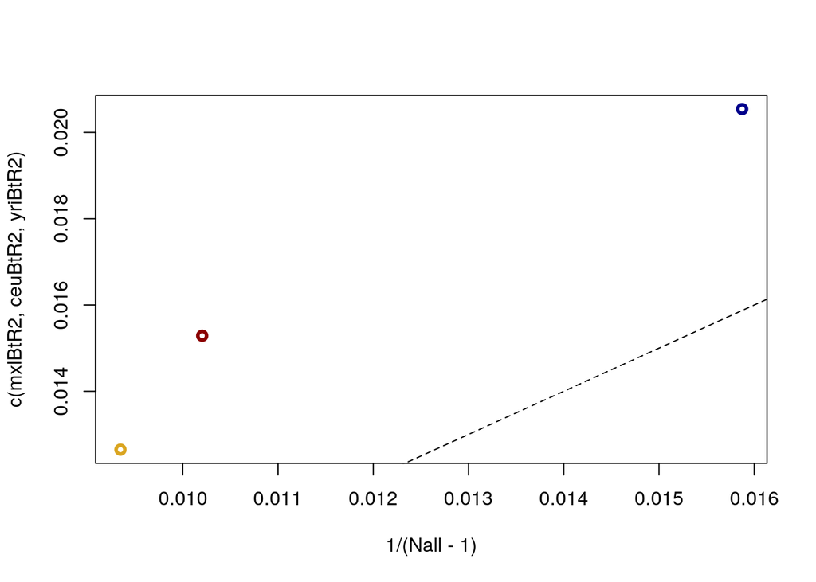

```r
plot(1/(Nall-1),c(mxlBtR2,ceuBtR2,yriBtR2),lwd=3,col=c("darkblue","darkred","goldenrod"))
abline(0,1,lty=2)
```

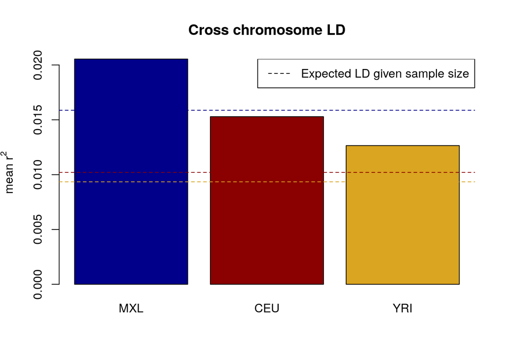

```r
barplot(c(mxlBtR2,ceuBtR2,yriBtR2),col=c("darkblue","darkred","goldenrod"),beside=T,names=c("MXL","CEU","YRI"),main="Cross chromosome LD",ylab=ylabr2)
abline(h=1/(Nall-1),lty=2,col=c("darkblue","darkred","goldenrod") )
legend("topright",lty=2,"Expected LD given sample size")
```